# Gadiel_Shepherd_Project2_full_code_notebook

## Problem Statement

### Context

AllLife Bank is a US bank that has a growing customer base. The majority of these customers are liability customers (depositors) with varying sizes of deposits. The number of customers who are also borrowers (asset customers) is quite small, and the bank is interested in expanding this base rapidly to bring in more loan business and in the process, earn more through the interest on loans. In particular, the management wants to explore ways of converting its liability customers to personal loan customers (while retaining them as depositors).

A campaign that the bank ran last year for liability customers showed a healthy conversion rate of over 9% success. This has encouraged the retail marketing department to devise campaigns with better target marketing to increase the success ratio.

You as a Data scientist at AllLife bank have to build a model that will help the marketing department to identify the potential customers who have a higher probability of purchasing the loan.

### Objective

To predict whether a liability customer will buy personal loans, to understand which customer attributes are most significant in driving purchases, and identify which segment of customers to target more.

### Data Dictionary

- `ID`: Customer ID
- `Age`: Customer’s age in completed years
- `Experience`: #years of professional experience
- `Income`: Annual income of the customer (in thousand dollars)
- `ZIP Code`: Home Address ZIP code.
- `Family`: the Family size of the customer
- `CCAvg`: Average spending on credit cards per month (in thousand dollars)
- `Education`: Education Level. 1: Undergrad; 2: Graduate;3: Advanced/Professional
- `Mortgage`: Value of house mortgage if any. (in thousand dollars)
- `Personal_Loan`: Did this customer accept the personal loan offered in the last campaign? (0: No, 1: Yes)
- `Securities_Account`: Does the customer have securities account with the bank? (0: No, 1: Yes)
- `CD_Account`: Does the customer have a certificate of deposit (CD) account with the bank? (0: No, 1: Yes)
- `Online`: Do customers use internet banking facilities? (0: No, 1: Yes)
- `CreditCard`: Does the customer use a credit card issued by any other Bank (excluding All life Bank)? (0: No, 1: Yes)

## Importing necessary libraries

**Note**:

```python
# Importing the relevant libraries
import pandas as pd
import numpy as np
import matplotlib.pyplot as plt
import seaborn as sns
from sklearn.tree import DecisionTreeClassifier
from sklearn.model_selection import train_test_split
from sklearn.model_selection import GridSearchCV
from sklearn import tree
from sklearn.metrics import (
    confusion_matrix,
    accuracy_score,
    recall_score,
    precision_score,
    f1_score,
)
# To ignore unnecessary warnings
import warnings
warnings.filterwarnings("ignore")
```

## Loading the dataset

```python
# Mounting drive to colab
from google.colab import drive
drive.mount('/content/drive')
```

```python
# Loading the csv file into a dataframe
path="/content/drive/MyDrive/AIML/M2_Machine_Learning/Project/Loan_Modelling.csv"
loan_data=pd.read_csv(path)

# Creating a copy of the dataframe (so the orginal dataframe remains unchanged)
df=loan_data.copy()
```

## Data Overview

- Observations
- Sanity checks

```python
# Observing first 5 rows of the dataframe
df.head()
```

|  | ID | Age | Experience | Income | ZIPCode | Family | CCAvg | Education | Mortgage | Personal_Loan | Securities_Account | CD_Account | Online | CreditCard |
| --- | --- | --- | --- | --- | --- | --- | --- | --- | --- | --- | --- | --- | --- | --- |
| 0 | 1 | 25 | 1 | 49 | 91107 | 4 | 1.6 | 1 | 0 | 0 | 1 | 0 | 0 | 0 |
| 1 | 2 | 45 | 19 | 34 | 90089 | 3 | 1.5 | 1 | 0 | 0 | 1 | 0 | 0 | 0 |
| 2 | 3 | 39 | 15 | 11 | 94720 | 1 | 1.0 | 1 | 0 | 0 | 0 | 0 | 0 | 0 |
| 3 | 4 | 35 | 9 | 100 | 94112 | 1 | 2.7 | 2 | 0 | 0 | 0 | 0 | 0 | 0 |
| 4 | 5 | 35 | 8 | 45 | 91330 | 4 | 1.0 | 2 | 0 | 0 | 0 | 0 | 0 | 1 |

```python
# Checking rows and columns
df.shape
```

```
(5000, 14)
```

### Observations:

- There are 5000 rows and 14 columns.

```python
# Checking data types of the variables
df.info()
```

```
<class 'pandas.core.frame.DataFrame'>
RangeIndex: 5000 entries, 0 to 4999
Data columns (total 14 columns):
 #   Column              Non-Null Count  Dtype
---  ------              --------------  -----
 0   ID                  5000 non-null   int64
 1   Age                 5000 non-null   int64
 2   Experience          5000 non-null   int64
 3   Income              5000 non-null   int64
 4   ZIPCode             5000 non-null   int64
 5   Family              5000 non-null   int64
 6   CCAvg               5000 non-null   float64
 7   Education           5000 non-null   int64
 8   Mortgage            5000 non-null   int64
 9   Personal_Loan       5000 non-null   int64
 10  Securities_Account  5000 non-null   int64
 11  CD_Account          5000 non-null   int64
 12  Online              5000 non-null   int64
 13  CreditCard          5000 non-null   int64
dtypes: float64(1), int64(13)
memory usage: 547.0 KB
```

### Observations:

- All variables are numerical data type.
- However ID and ZIPCode represent categorical data, and therefore will need to dealt with later.

```python
# Statistical summary
df.describe().T
```

|  | count | mean | std | min | 25% | 50% | 75% | max |
| --- | --- | --- | --- | --- | --- | --- | --- | --- |
| ID | 5000.0 | 2500.500000 | 1443.520003 | 1.0 | 1250.75 | 2500.5 | 3750.25 | 5000.0 |
| Age | 5000.0 | 45.338400 | 11.463166 | 23.0 | 35.00 | 45.0 | 55.00 | 67.0 |
| Experience | 5000.0 | 20.104600 | 11.467954 | -3.0 | 10.00 | 20.0 | 30.00 | 43.0 |
| Income | 5000.0 | 73.774200 | 46.033729 | 8.0 | 39.00 | 64.0 | 98.00 | 224.0 |
| ZIPCode | 5000.0 | 93169.257000 | 1759.455086 | 90005.0 | 91911.00 | 93437.0 | 94608.00 | 96651.0 |
| Family | 5000.0 | 2.396400 | 1.147663 | 1.0 | 1.00 | 2.0 | 3.00 | 4.0 |
| CCAvg | 5000.0 | 1.937938 | 1.747659 | 0.0 | 0.70 | 1.5 | 2.50 | 10.0 |
| Education | 5000.0 | 1.881000 | 0.839869 | 1.0 | 1.00 | 2.0 | 3.00 | 3.0 |
| Mortgage | 5000.0 | 56.498800 | 101.713802 | 0.0 | 0.00 | 0.0 | 101.00 | 635.0 |
| Personal_Loan | 5000.0 | 0.096000 | 0.294621 | 0.0 | 0.00 | 0.0 | 0.00 | 1.0 |
| Securities_Account | 5000.0 | 0.104400 | 0.305809 | 0.0 | 0.00 | 0.0 | 0.00 | 1.0 |
| CD_Account | 5000.0 | 0.060400 | 0.238250 | 0.0 | 0.00 | 0.0 | 0.00 | 1.0 |
| Online | 5000.0 | 0.596800 | 0.490589 | 0.0 | 0.00 | 1.0 | 1.00 | 1.0 |
| CreditCard | 5000.0 | 0.294000 | 0.455637 | 0.0 | 0.00 | 0.0 | 1.00 | 1.0 |

### Observations:

- The minimum value for experience is -3, this will need to be investigated.

```python
# Checking for duplicate rows
df.duplicated().sum()
```

```
np.int64(0)
```

### Observations:

- There are no duplicate rows.

## Exploratory Data Analysis.

- EDA is an important part of any project involving data.
- It is important to investigate and understand the data better before building a model with it.
- A few questions have been mentioned below which will help you approach the analysis in the right manner and generate insights from the data.
- A thorough analysis of the data, in addition to the questions mentioned below, should be done.

**Questions**:

1. What is the distribution of mortgage attribute? Are there any noticeable patterns or outliers in the distribution?
2. How many customers have credit cards?
3. What are the attributes that have a strong correlation with the target attribute (personal loan)?
4. How does a customer's interest in purchasing a loan vary with their age?
5. How does a customer's interest in purchasing a loan vary with their education?

### Defining functions for plotting distributions

```python
# Function to plot a histogram and boxplot

def histogram_boxplot(data, feature, figsize=(10, 6), kde=False, bins=None):
    """
    Boxplot and histogram combined

    data: dataframe
    feature: dataframe column
    figsize: size of figure (default (15,10))
    kde: whether to show the density curve (default False)
    bins: number of bins for histogram (default None)
    """
    f2, (ax_box2, ax_hist2) = plt.subplots(
        nrows=2,  # Number of rows of the subplot grid= 2
        sharex=True,  # x-axis will be shared among all subplots
        gridspec_kw={"height_ratios": (0.25, 0.75)},
        figsize=figsize,
    )  # creating the 2 subplots
    sns.boxplot(
        data=data, x=feature, ax=ax_box2, showmeans=True, color="violet"
    )  # boxplot will be created and a triangle will indicate the mean value of the column
    sns.histplot(
        data=data, x=feature, kde=kde, ax=ax_hist2, bins=bins
    ) if bins else sns.histplot(
        data=data, x=feature, kde=kde, ax=ax_hist2
    )  # For histogram
    ax_hist2.axvline(
        data[feature].mean(), color="green", linestyle="--"
    )  # Add mean to the histogram
    ax_hist2.axvline(
        data[feature].median(), color="black", linestyle="-"
    )  # Add median to the histogram
    # Print min, max, mean and median value
    print("Min:{:.2f} Max:{:.2f} Mean:{:.2f} Median:{:.2f}".format(
        data[feature].min(),
        data[feature].max(),
        data[feature].mean(),
        data[feature].median()
    ))
```

```python
# Function to create labeled barplots

def labeled_barplot(data, feature, perc=False, n=None):
    """
    Barplot with percentage at the top

    data: dataframe
    feature: dataframe column
    perc: whether to display percentages instead of count (default is False)
    n: displays the top n category levels (default is None, i.e., display all levels)
    """

    total = len(data[feature])  # length of the column
    count = data[feature].nunique()
    if n is None:
        plt.figure(figsize=(count + 2, 6))
    else:
        plt.figure(figsize=(n + 2, 6))

    plt.xticks(rotation=90, fontsize=15)
    ax = sns.countplot(
        data=data,
        x=feature,
        palette="Paired",
        order=data[feature].value_counts().index[:n],
    )

    for p in ax.patches:
        if perc == True:
            label = "{:.1f}%".format(
                100 * p.get_height() / total
            )  # percentage of each class of the category
        else:
            label = p.get_height()  # count of each level of the category

        x = p.get_x() + p.get_width() / 2  # width of the plot
        y = p.get_height()  # height of the plot

        ax.annotate(
            label,
            (x, y),
            ha="center",
            va="center",
            size=12,
            xytext=(0, 5),
            textcoords="offset points",
        )  # annotate the percentage

    plt.show()  # show the plot
```

```python
# Function to plot a stacked barplot

def stacked_barplot(data, predictor, target):
    """
    Print the category counts and plot a stacked bar chart

    data: dataframe
    predictor: independent variable
    target: target variable
    """
    count = data[predictor].nunique()
    sorter = data[target].value_counts().index[-1]
    tab1 = pd.crosstab(data[predictor], data[target], margins=True).sort_values(
        by=sorter, ascending=False
    )
    print(tab1)
    print("-" * 120)
    tab = pd.crosstab(data[predictor], data[target], normalize="index").sort_values(
        by=sorter, ascending=False
    )
    tab.plot(kind="bar", stacked=True, figsize=(count + 5, 5))
    plt.legend(
        loc="lower left", frameon=False,
    )
    plt.legend(loc="upper left", bbox_to_anchor=(1, 1))
    plt.show()
```

```python
# Function to plot distributions with relation to the target variable

def distribution_plot_wrt_target(data, predictor, target):

    fig, axs = plt.subplots(2, 2, figsize=(12, 10))

    target_uniq = data[target].unique()

    axs[0, 0].set_title("Distribution of target for target=" + str(target_uniq[0]))
    sns.histplot(
        data=data[data[target] == target_uniq[0]],
        x=predictor,
        kde=True,
        ax=axs[0, 0],
        color="teal",
        stat="density",
    )

    axs[0, 1].set_title("Distribution of target for target=" + str(target_uniq[1]))
    sns.histplot(
        data=data[data[target] == target_uniq[1]],
        x=predictor,
        kde=True,
        ax=axs[0, 1],
        color="orange",
        stat="density",
    )

    axs[1, 0].set_title("Boxplot w.r.t target")
    sns.boxplot(data=data, x=target, y=predictor, ax=axs[1, 0], palette="gist_rainbow")

    axs[1, 1].set_title("Boxplot (without outliers) w.r.t target")
    sns.boxplot(
        data=data,
        x=target,
        y=predictor,
        ax=axs[1, 1],
        showfliers=False,
        palette="gist_rainbow",
    )

    plt.tight_layout()
    plt.show()
```

## Univariate Analysis

```
Min:23.00 Max:67.00 Mean:45.34 Median:45.00
```

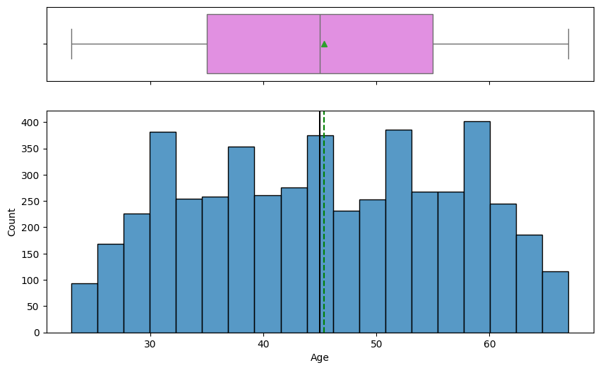

```python
# Plotting the distribution for Age using a boxplot and histogram
histogram_boxplot(data=df, feature='Age')
```

### Observations for Age:

- The distribution for is symmetrically distributed.
- There are no outliers.
- The youngest customer is 23, the oldest is 67, the average is 45.34 and the median is 45.

```
Min:-3.00 Max:43.00 Mean:20.10 Median:20.00
```

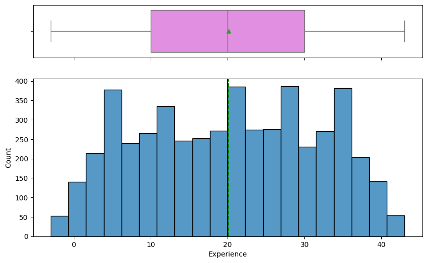

```python
# Plotting the distribution for Experience using a boxplot and histogram
histogram_boxplot(data=df, feature='Experience')
```

### Observations for Experience:

- The distribution for is symmetrically distributed.
- There are no outliers.
- The lowest experience is -3 years which cannot be true and this will be investigated and corrected before building the model. The highest experience is 43 years with an average of 20.10 and a median of 20.

```
Min:8.00 Max:224.00 Mean:73.77 Median:64.00
```

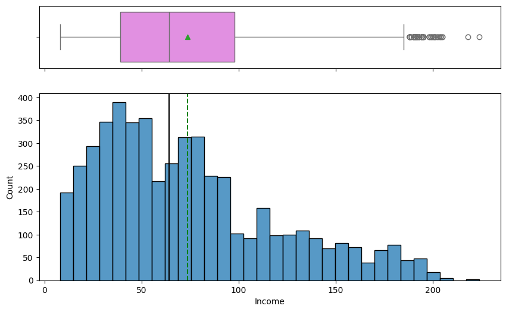

```python
# Plotting the distribution for Income using a boxplot and histogram
histogram_boxplot(data=df, feature='Income')
```

### Observations for Income:

- The distribution is right-skewed.
- There are customers who have an abnormally higher income in relation to the rest of the customers.
- The lowest annual income is 8K dollars, the highest is 224K, the average is 73.77K and the median is 64K.

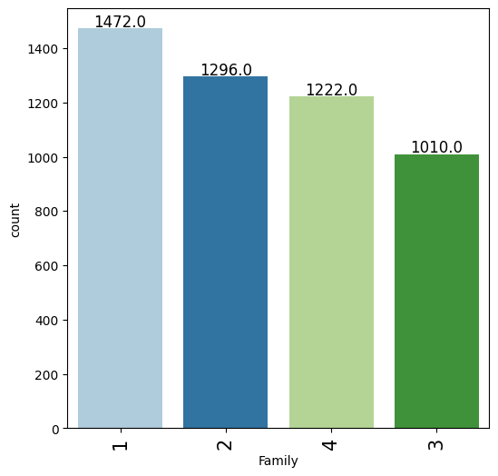

```python
# Plotting the distribution for Family using a barplot
labeled_barplot(data=df, feature='Family')
```

### Observations for Family:

- Most customers have a family size of 1.
- There are no customers who have a family size bigger than 4.

```
Min:0.00 Max:10.00 Mean:1.94 Median:1.50
```

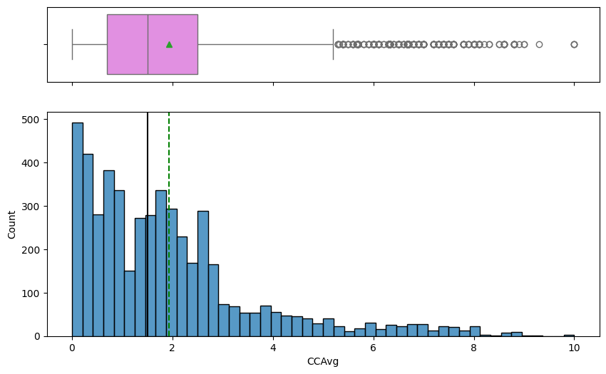

```python
# Plotting the distribution for CCAvg using a boxplot and histogram
histogram_boxplot(data=df, feature='CCAvg')
```

### Observations for CCAvg:

- The distribution is right-skewed.
- There are customers who have spend abnormally more on their credit card per month in relation to the rest of the customers.
- The lowest monthly spending on credit cards is 0 dollars, the highest 10K, with an average of 1.94K and a median of 1.5K.

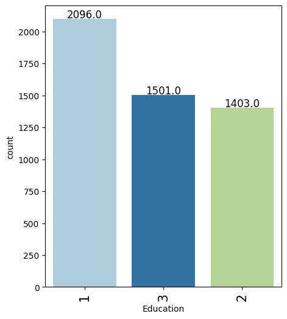

```python
# Plotting the distribution for Education using a barplot
labeled_barplot(data=df, feature='Education')
```

### Observations for Education:

- Most customers have an Undergraduate eductation level.
- Graduate is the least represented education level among the customers.

```
Min:0.00 Max:635.00 Mean:56.50 Median:0.00
```

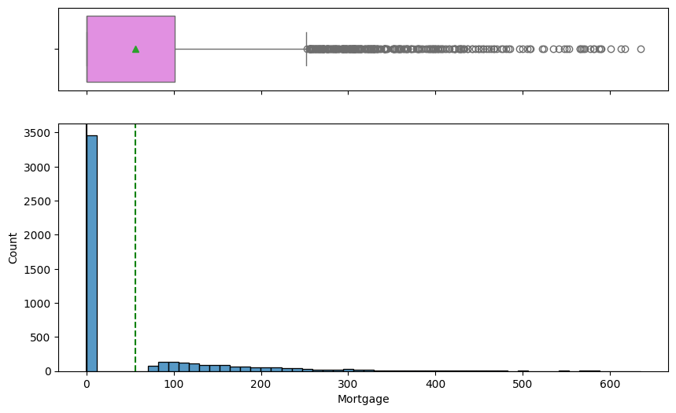

```python
# Plotting the distribution for Mortgage among all customers using a boxplot and histogram
histogram_boxplot(data=df, feature='Mortgage')
```

```
There are 3462 houses with no mortgage and there are 1538 houses with a mortgage.
------------------------------------------------------------------------------------------------------------------------------------------------------
Min:75.00 Max:635.00 Mean:183.68 Median:153.00
```

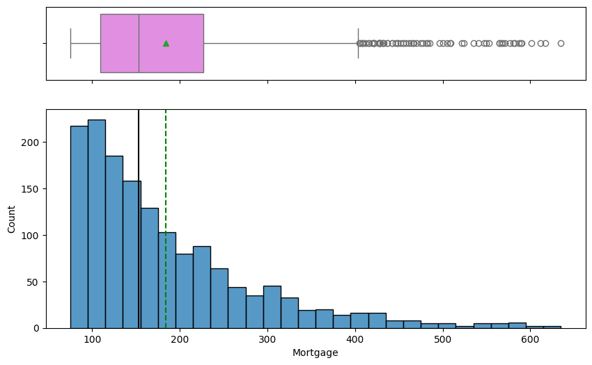

```python
# Counting number of customers with and without a mortgage
print('There are',(df['Mortgage'] == 0).sum(),'houses with no mortgage and there are',(df['Mortgage'] > 0).sum(),'houses with a mortgage.')
print('-'*150)
# Filtering the dataframe for customers with a mortgage
df_mortgage=df[df['Mortgage']>0]
# Plotting the distribution for Mortgage among customers who do have a mortgage using a boxplot and histogram
histogram_boxplot(data=df_mortgage, feature='Mortgage')
```

### Observations on Mortgage:

- The majority of customers do not have a mortgage (3462).
- Out of the customers that do have a mortgage (1538), there is a right-skewed distribution, where there are customers who have an abnormally high mortgage in relation to others.
  - Lowest mortgage is 75K dollars, the highest is 635K, with an average of 183.68K and a median of 153K.

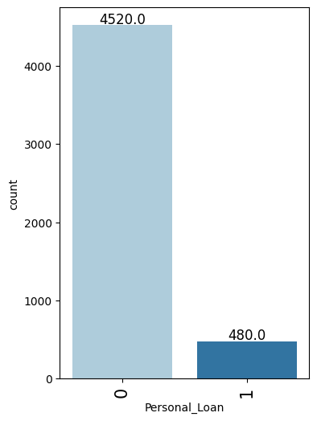

```python
# Plotting the distribution for Personal_Loan using a barplot
labeled_barplot(data=df, feature='Personal_Loan')
```

### Observations on Personal_Loan:

- Most of the customers (4520) have not taken out a loan in the last campaign.
- 480 customers did take out a loan.

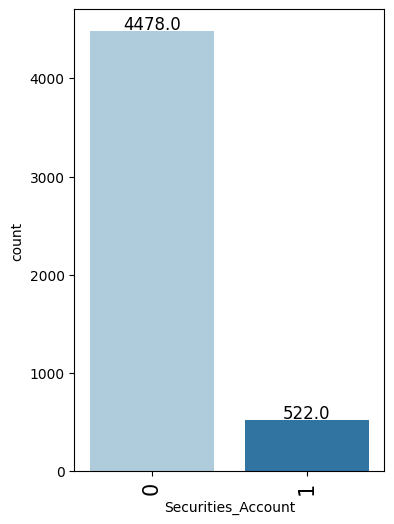

```python
# Plotting the distribution for Securities_Account using a barplot
labeled_barplot(data=df, feature='Securities_Account')
```

### Observations on Securities_Account:

- Most customers (4478) do not have a securities account with the bank.

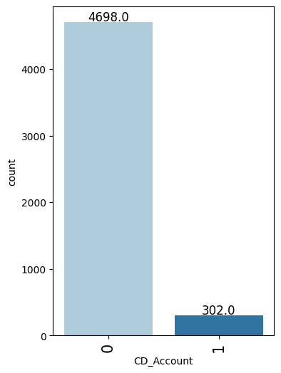

```python
# Plotting the distribution for CD_Account using a barplot
labeled_barplot(data=df, feature='CD_Account')
```

### Observations on CD_Account:

- Most customers (4698) do not have a certificate of deposit account with the bank.

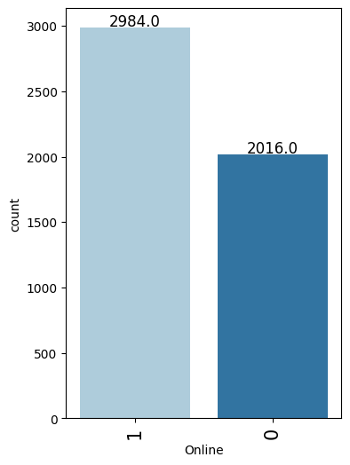

```python
# Plotting the distribution for Online using a barplot
labeled_barplot(data=df, feature='Online')
```

### Observations on Online:

- Most customers (2984) do use internet banking facilities.

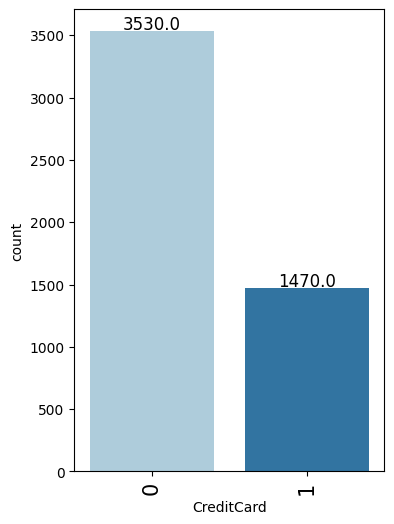

```python
# Plotting the distribution for CreditCard using a barplot
labeled_barplot(data=df, feature='CreditCard')
```

### Observations on Credit Card:

- The minority of customers (1470) do use a credit card issued by another bank.